# R Weather Project

Óðinn Eldon Ragnarsson, Oren Raz

1/22/2020

## R Weather Projecet By Oren Raz and Óðinn Eldon Ragnarsson

HÍ ID’s: orr3 and oer2 respectively

## Part a)

Column names changed to more convenient english names.

```r
#renames columns
oo = oo %>% rename("station" = "stöð",
                   "year" = "ár",
                   "month" = "mán",
                   "avg_temp" = "t",
                   "avg_high_temp" = "tx",
                   "peak" = "txx",
                   "peak_date" = "txxD1",
                   "avg_low" = "tn",
                   "low" = "tnn",
                   "low_date" = "tnnD1",
                   "avg_humidity" = "rh",
                   "precip" = "r",
                   "24h_precip_peak" = "rx",
                   "24h_precip_peak_date" = "rxD1",
                   "avg_pressure" = "p",
                   "avg_cloudcover" = "n",
                   "sun_hrs" = "sun",
                   "avg_windspeed" = "f",)
```

## Part b)

Factorizes data, this becomes critical later for creating plots and graphics.

```r
#Factorizes the station and month columns
oo$station <- as.factor(oo$station)
oo$month <- as.factor(oo$month)

#Makes factors for Reykjavik and Akureyri
oo$station <- recode_factor(oo$station, `1`="RvK")
oo$station <- recode_factor(oo$station, `422`="Ak")
```

## Part c)

Here we create a new column for seasons and assign a season value based on month. Dec-Feb is winter, Mar-May is spring et.c.

```r
#Makes season column and assigns approrpiate seasons
oo <- oo %>% mutate(season = recode_factor(month, "1"="winter", "2"="winter",
"12"="winter", "3"="spring",
"4"="spring","5"="spring","6"="summer","7"="summer",
"8"="summer","9"="autumn","10"="autumn","11"="autumn"))
```

## Part d1)

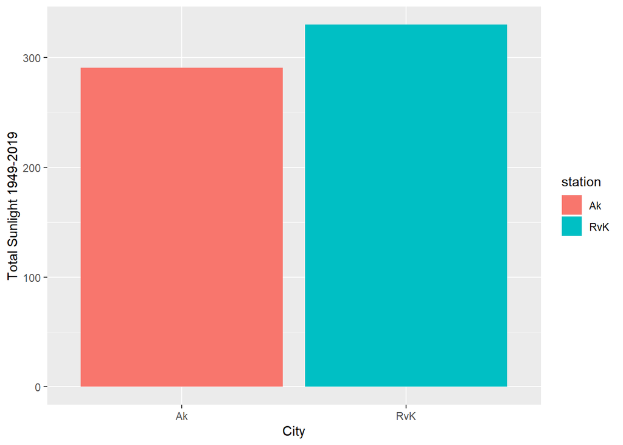

```r
#histogram/plot of total sunlight hours in Reykjavik and Akureyri (d1)
ggplot(oo, aes(fill=station, y=sun_hrs, x=station)) +
  geom_bar(position="dodge", stat="identity") + labs(x = "City", y = "Total Sunlight 1949-2019")
```

Based off this inforation it would be reasonable to assume that Akureyri is around obstacles that block the sun such as mountains or is overcast more often

## Part d2)

Here we compare mean monthly sunlight by month between Reykavik and Akureyri.

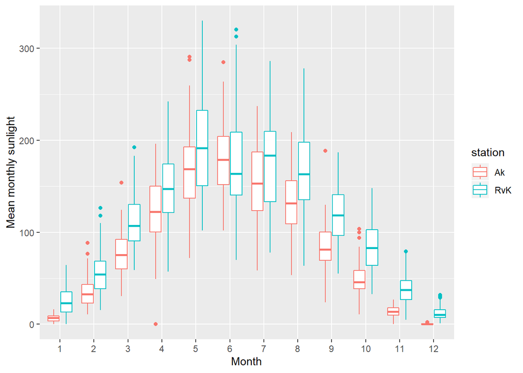

```r
#Average sun hours for each month box plot
oo %>%
  ggplot(aes(x=month, y=sun_hrs, col=station)) +
  geom_boxplot() + labs(x = "Month", y = "Mean monthly sunlight")
```

As concluded previously Akureyri recives less overall sunlight but based on even less sunlight in winter it may be concluded that Akureyri is closer to one of the poles than Reykjavik. It can also be inferred that both cities are in the northern hemesphere based on the increased sunlight in the mid year.

## Part e1)

Here we plot the temperature by season for Reykjavik and Akureyri

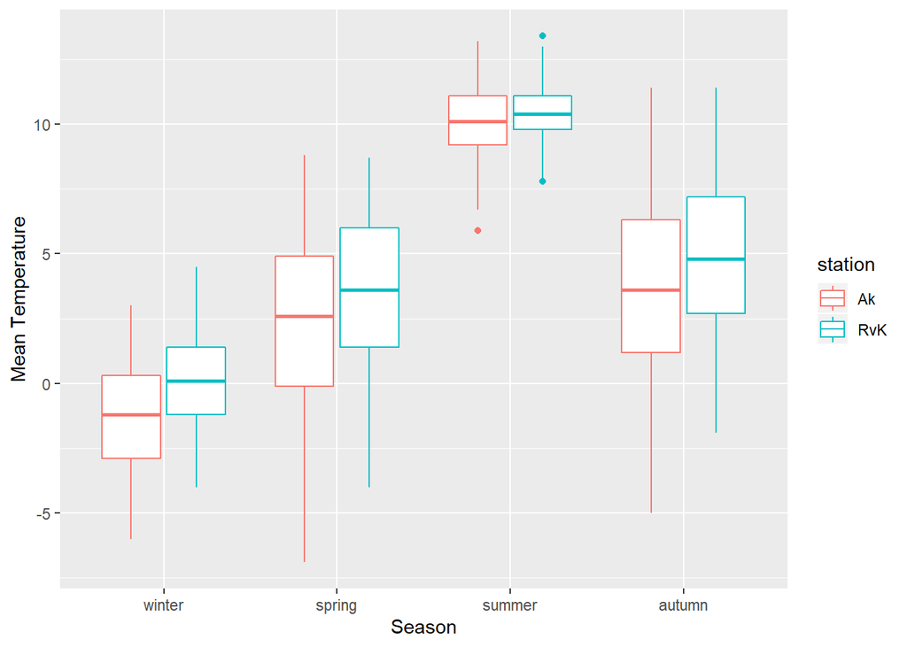

```r
#Plots mean temperature by season
oo %>%
  ggplot(aes(x=season, y=avg_temp, col=station)) +
  geom_boxplot() + labs(x = "Season", y = "Mean Temperature")
```

Overall Reykjavik has higher average temperature than Akureyri. This also supports the idea that Reykjavik is closer to the equator than Akureyri. It may also be assumed that the two cities share a similar climate as the temperature ranges are very similar throughout each season.

## Part e2)

Here we see a plot of sunlight by season for Reykjavik and Akureyri

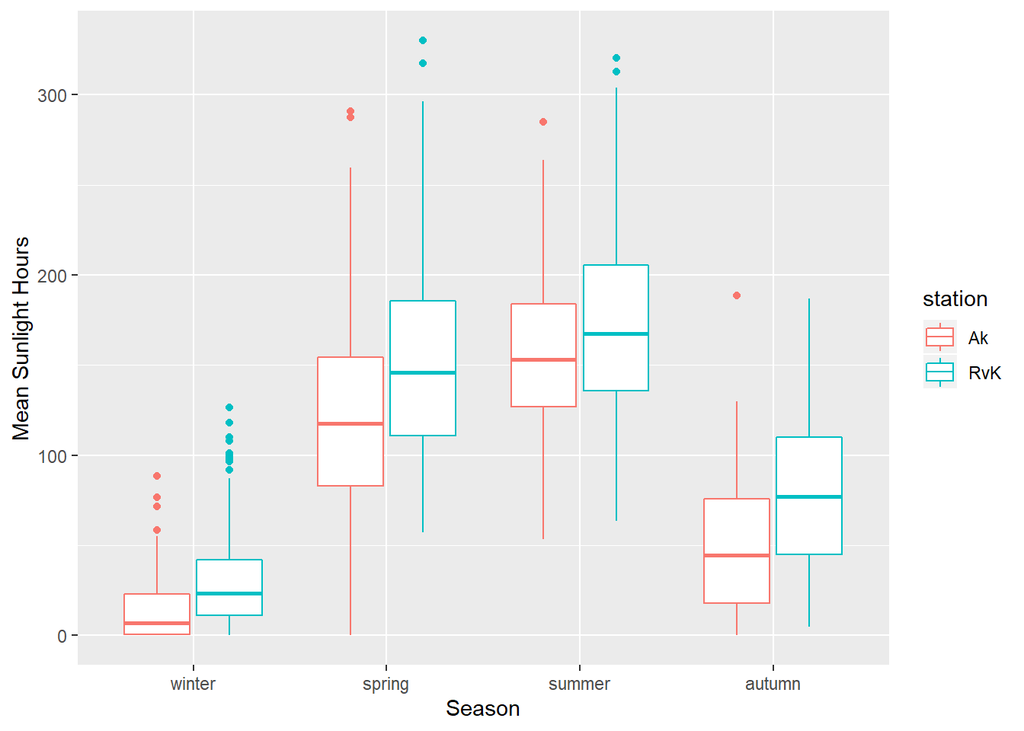

```r
##Plots mean sunlighthours by season
oo %>%
  ggplot(aes(x=season, y=sun_hrs, col=station)) +
  geom_boxplot()+ labs(x = "Season", y = "Mean Sunlight Hours")
```

As stated before, based on this plot, it can be inferred that both cities are in the northern hemesphere. They also appear to have a similar longitude based on very similar patterns of sunshine.

## Part e3)

Last of the season plots we have the mean precipitation by season

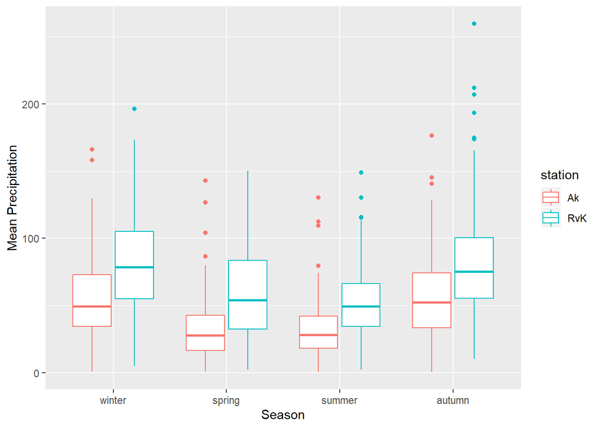

```r
#Plots mean precipitation by season
oo %>%
  ggplot(aes(x=season, y=precip, col=station)) +
  geom_boxplot() + labs(x = "Season", y = "Mean Precipitation")
```

There is considerably less rain in Akureyri. Since we have already determined that both cities are at very similar longitude and likely also latitude it is possible that as was noted before as a possibility that significant terrain such as mountains surrounds Akureyri, fully or partially limiting rainfall.

## Part f)

Here we find quite possibly the worst plot of this report. Mean precipitation v atmosperic pressure

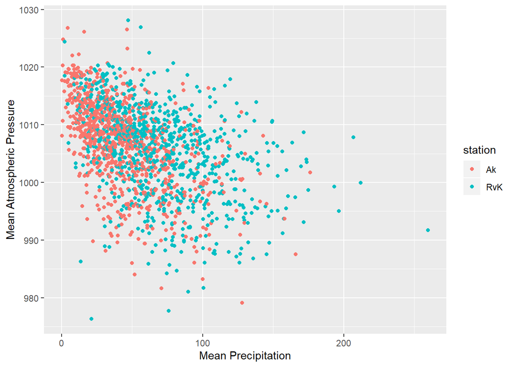

```r
#Plots mean precipitation v mean atmospheric pressure
ggplot(oo, aes(fill=station, y=avg_pressure, x=precip, col=station)) +
 geom_point(position="dodge", stat="identity") + labs(x = "Mean Precipitation", y = "Mean Atmospheric Pressure")
```

This shows a weak trend that with lower atmospheric pressure mean precipitation is higher. Other than that there isn’t much that can be inferred from this plot this trend however does agree with the authors’ limited knowledge on meteorology.

## Part g)

here we have a table with various values pertaining to average weather patterns from 1949 to 2019.

```r
#Creates a table with various stats by city and season
oo <- group_by(oo, station, season)
summaryTable <- summarise(oo,"mean sun hours" = mean(sun_hrs, na.rm=T),
                        "S.D sun hours" = sd(sun_hrs, na.rm=T),
                        "mean precipitation" = mean(precip),
                        "Average temp" = mean(avg_temp))

print (summaryTable)
```

```
## # A tibble: 8 x 6
## # Groups:   station [2]
##   station season `mean sun hours` `S.D sun hours` `mean precipita…
##   <fct>   <fct>             <dbl>           <dbl>            <dbl>
## 1 Ak      winter             14.0            17.5             54.1
## 2 Ak      spring            123.             51.0             32.1
## 3 Ak      summer            155.             43.4             31.9
## 4 Ak      autumn             50.1            34.9             55.9
## 5 RvK     winter             31.2            25.9             82.3
## 6 RvK     spring            153.             55.6             61.0
## 7 RvK     summer            172.             51.7             52.3
## 8 RvK     autumn             80.7            41.8             79.9
## # … with 1 more variable: `Average temp` <dbl>
```

Span of data set in years (as it appears in database)

```r
min(oo[,"year"], na.rm=T)
```

```
## [1] 1949
```

```r
max(oo[,"year"], na.rm=T)
```

```
## [1] 2019
```

## Part h)

here we have a chunk that calculates three values and prints them out.

```r
#finish the group by
oo <- group_by(oo)
# Average sun hours combined:
avgSnHr <- summarise(oo, t = mean(sun_hrs, na.rm = T))$t

Ak_months_above_avg <- nrow(filter(oo, sun_hrs > avgSnHr, station == "Ak"))
RvK_months_above_avg <- nrow(filter(oo, sun_hrs > avgSnHr, station == "RvK"))
```

The three values are the average sunlight hours across Reykjavik and Akureyri, the number of months Akureyri was above the average and the number of months Reykjavik was above the average respectfully.

```r
print(avgSnHr)
```

```
## [1] 97.85378
```

```r
print (Ak_months_above_avg)
```

```
## [1] 352
```

```r
print (RvK_months_above_avg)
```

```
## [1] 451
```

## Part i)

These chuncks get values of the highest recored precipitation in the span of 24 hours and the date of said 24 hours for both Reykjavik and Akureyri.

```r
# Fitlters out unwanted city rows, finds the row of the 24hr peak rain, and prints it
#Reykjavik
oot = filter(oo, station == "RvK")
oot = slice(oot, which.max(oot$`24h_precip_peak`))
oot = oot %>% select(year, month, `24h_precip_peak_date`, `24h_precip_peak` )
glimpse(oot)
```

```
## Observations: 1
## Variables: 4
## $ year                   <dbl> 2012
## $ month                  <fct> 12
## $ `24h_precip_peak_date` <dbl> 29
## $ `24h_precip_peak`      <dbl> 54.6
```

```r
#Akureyri
oot = filter(oo, station == "Ak")
oot = slice(oot, which.max(oot$`24h_precip_peak`))
oot = oot %>% select(year, month, `24h_precip_peak_date`, `24h_precip_peak` )
glimpse(oot)
```

```
## Observations: 1
## Variables: 4
## $ year                   <dbl> 1950
## $ month                  <fct> 8
## $ `24h_precip_peak_date` <dbl> 25
## $ `24h_precip_peak`      <dbl> 52
```

Akureyri: highest recored precipitation in the span of 24 hours was 52, on 25. August 1950